# An Analysis on Endangered and Extinct Fauna and Flora

Panthers

29/01/2022

## Team Members

Serdar Eren Mersin - 090180362

## Addressed Social Problem and the Project Goal

The goal of this project is to show endangerment and extinction increase and general endangerement and extinction data using visualization tools.

## Project Data

The data is provided by International Union for Conservation of Nature’s Red List of Threatened Species (IUCN for short).

- [Estimated Number, Described and Threatened Species by Major Group of Organisms and Numbers of Threatened Species Grouped by Year](https://www.iucnredlist.org/resources/summary-statistics)
- [Numbers of Species in each IUCN Red List by kingdom and class (table 3)](https://www.iucnredlist.org/statistics)
- [Threatened Sprecies Grouped by Country (table 5)](https://www.iucnredlist.org/statistics)

## Project Description

Before looking at the work on the data, the first thing to do is to describe how IUCN describes animals. These are the scales:

1. Data Deficient (DD)
- These animals or plants do not have enough information to asses if it is endangered or not.
- The species can be well studied, it just does not have appropriate data for endangerement risk evaluation.
2. Least Concern (LC)
- This category is for the animals or plants that do not fit the other categories below.
3. Near Threatened (NT)
- This category is for the animals or plants that do not fit the other categories below.
- Unlike Least Concern however, this category means that the animal or plant that listed is close to being endangered.
4. Vulnerable (VU), Endangered (EN) and Critically Endangered (CR)
- These animals or plants are in the high risk of extinction, with Vulnerable being the least severe and Critically Endangered being the most severe.
5. Extinct in the Wild (EW)
- These animals or plants are now not alive in the wild anymore, and only living in captivity or in cultivation.
6. Extinct (EX)
- These animals or plants are known that there are certainly no individual alive anymore.
7. Possibly Extinct (CR(PE)) and Possibly Extinct in the Wild (CR(PEW))
- These animals or plants have a very high chance that they are extinct or extinct in the wild.
- This data is calculated separately in the plots.

Another thing to note about the data is that IUCN does their endangerment calculation by dividing the count of endangered animals by the count of animals evaluated by them. This approach was used in this report as well. IUCN calculates calculates three percentages for endangerment; lower, best and higher. Lower does not take the data deficient species in its calculation, best estimate adds half of it into account, and higher takes all of the data deficient species. In this paper, the percent was calculated using the lower percent rule.

## Preliminary Results and Codes

The first step is to do some cleaning in the data.

```r
yearly_threat_table <- read_csv("data/Number of Threatened Species Yearly.csv", na = c("-"), show_col_types = FALSE)
relation_table <- read_csv("data/Number of Species Evaluated in Relation to Overall Number of Described Species.csv", show_col_types = FALSE)
detailed_table <- read_csv("data/Table 3  Species by kingdom and class - show all.csv", show_col_types = FALSE) %>%
  select(-c("Subtotal (EX+EW+ CR(PE)+CR(PEW))", "Subtotal (threatened spp.)", "LR/cd", "Subtotal (EX+EW)", "Total")) %>%
  rename("LC" = "LC or LR/lc", "NT" = "NT or LR/nt", "PE" = "CR(PE)", "PEW" = "CR(PEW)")

# Pick the necessary data
total_nums <- relation_table %>%
  select(c("Animal Type", "Estimated Number OF Described Species", "Number of species evaluated by 2021 (IUCN Red List version 2021-2)"))
```

The next step is to visualize the data. The visualization is categorized by the classes.

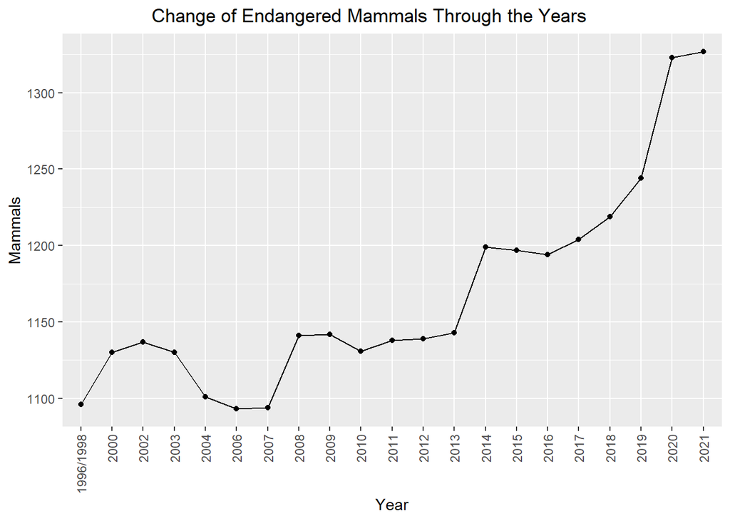

```r
yearly_threat_table %>%
  select(c("Year", "Assesment Type", "Mammals")) %>%
  filter(grepl("Total threatened", yearly_threat_table$`Assesment Type`)) %>%
  ggplot(aes(x = Year, y = Mammals, group = 1)) + geom_line() + geom_point() + labs(title = "Change of Endangered Mammals Through the Years") + theme(plot.title = element_text(hjust = 0.4), axis.text.x = element_text(angle = 90, hjust = 1, vjust = 0.5))
```

```r
total_nums %>%
  filter(grepl("Mammals", total_nums$`Animal Type`)) -> temp

detailed_table %>%
  filter(grepl("MAMMALIA", detailed_table$Name)) %>%
  add_column("Species Count" = temp[[2]]) %>%
  add_column("Evaluated Count" = temp[[3]]) %>%
  select(-c("Name")) %>%
  mutate(Endangered = CR + EN + VU, Extinct = PEW + PE + EX + EW) %>%
  select(c("Endangered", "Extinct", "Evaluated Count", "Species Count", "LC", "DD", "NT")) %>%
  gather(Stats, Amount) -> mammal_data

  mammal_data %>%
    add_row(Stats = "Extinction Rate(percent)", Amount = mammal_data$Amount[2]/ mammal_data$Amount[3] * 100) %>%
    add_row(Stats = "Endangerement Rate(percent)", Amount = mammal_data$Amount[1] / mammal_data$Amount[3]* 100) %>%
  knitr::kable(caption = "Detailed Endangerment and Extinction Info for Mammals - 2021")
```

Detailed Endangerment and Extinction Info for Mammals - 2021

| Stats | Amount |
| --- | --- |
| Endangered | 1327.000000 |
| Extinct | 115.000000 |
| Evaluated Count | 5954.000000 |
| Species Count | 6554.000000 |
| LC | 3324.000000 |
| DD | 845.000000 |
| NT | 371.000000 |
| Extinction Rate(percent) | 1.931475 |
| Endangerement Rate(percent) | 22.287538 |